# Predicting the Minutes an NBA Player Should Be Given

## By Stefan Traska

The [National Basketball Association](https://www.nba.com), also known as the NBA, is the American and Canadian professional basketball league, featuring 30 teams from various cities. Throughout the regular season, teams play a total of 82 games, and the top 16 teams compete in the playoffs, where they must win 4 games out of 7 against each opponent to move on to the next round. Each team plays 5 players at a time, and there are 5 positions:

#### Point Guard (PG)

This position typically does most of the ball handling and runs the offense. These players are also typically smaller and are skilled in passing.

#### Shooting Guard (SG)

This position is similar to a point guard, but handles the ball a little less, and are usually good at shooting.

#### Small Forward (SF)

This position is a mix of a guard and a forward, and these players can guard any sized player.

#### Power Forward (PF)

This position has a similar role to a center, but these players are typically more versatile and agile.

#### Center (C)

This position contains the tallest players, and they play near the basket and get rebounds.

In this project, we will be analyzing player data from the 2019-2020 NBA regular season, and we will be using the data to create a model to predict a player's minutes played per game (or how many minutes they should play) based on how well they played during the season. For reference, an NBA game is 48 minutes.

```python
import pandas as pd
import numpy as np

import seaborn as sns
import plotly.express as px
import matplotlib.pyplot as plt

from sklearn.linear_model import LinearRegression
from sklearn.model_selection import train_test_split
pd.options.display.float_format = '{:,.2f}'.format
```

# Loading Data

```python
data = pd.read_csv('nba_2020_per_game.csv')
```

### Understanding the Variables

```
Key Variables to Know
  1. MP       Minutes Played Per Game
  2. FG       Field Goals Made Per Game - a field goal is a 2-point shot or 3-point shot
  3. 3P       3-Pointers Made Per Game
  4. FG%/3P%  Field Goal Percentage Made/3-Pointer Percentage Made
  5. TRB      Rebounds Per Game - a rebound is catching the ball after a missed shot
  6. AST      Assists Per Game -  an assist is a pass to a player who scores
  7. STL      Steals Per Game - a steal is taking the ball away from an opponent
  8. BLK      Blocks Per Game -  a block is hitting the ball away from the basket during a shot
  9. TOV      Turnovers Per Game - a turnover is when a player loses possession of the ball to the other team (shots do not count)
  10. PTS     Points Per Game - a free throw is 1 point, 2-pointers are inside the 3-point line, and 3-pointers are outside the 3-point line
```

# Data Exploration

The dataset can be found on Kaggle. We will fill in a dataframe with the data from the csv file given.

## Data Cleaning

First, we will replace statistics that are N/A with 0s, as it is likely that this statistic did not apply to the player.

```python
data = data.drop_duplicates().fillna(0)
```

```python
data = data[data.G > 25]
data = data.reset_index()
print(f"This data is conducted on {len(data.index)} NBA players during the 19-20 season.")
```

```
This data is conducted on 420 NBA players during the 19-20 season.
```

```python
data.head()
```

|  | index | Player | Pos | Age | Tm | G | GS | MP | FG | FGA | ... | FT% | ORB | DRB | TRB | AST | STL | BLK | TOV | PF | PTS |
| --- | --- | --- | --- | --- | --- | --- | --- | --- | --- | --- | --- | --- | --- | --- | --- | --- | --- | --- | --- | --- | --- |
| 0 | 0 | Steven Adams | C | 26 | OKC | 63 | 63 | 26.70 | 4.50 | 7.60 | ... | 0.58 | 3.30 | 6.00 | 9.30 | 2.30 | 0.80 | 1.10 | 1.50 | 1.90 | 10.90 |
| 1 | 1 | Bam Adebayo | PF | 22 | MIA | 72 | 72 | 33.60 | 6.10 | 11.00 | ... | 0.69 | 2.40 | 7.80 | 10.20 | 5.10 | 1.10 | 1.30 | 2.80 | 2.50 | 15.90 |
| 2 | 2 | LaMarcus Aldridge | C | 34 | SAS | 53 | 53 | 33.10 | 7.40 | 15.00 | ... | 0.83 | 1.90 | 5.50 | 7.40 | 2.40 | 0.70 | 1.60 | 1.40 | 2.40 | 18.90 |
| 3 | 4 | Nickeil Alexander-Walker | SG | 21 | NOP | 47 | 1 | 12.60 | 2.10 | 5.70 | ... | 0.68 | 0.20 | 1.60 | 1.80 | 1.90 | 0.40 | 0.20 | 1.10 | 1.20 | 5.70 |
| 4 | 5 | Grayson Allen | SG | 24 | MEM | 38 | 0 | 18.90 | 3.10 | 6.60 | ... | 0.87 | 0.20 | 2.00 | 2.20 | 1.40 | 0.30 | 0.10 | 0.90 | 1.40 | 8.70 |

5 rows × 30 columns

## Descriptive Statistics

```python
data.describe()
```

|  | index | Age | G | GS | MP | FG | FGA | FG% | 3P | 3PA | ... | FT% | ORB | DRB | TRB | AST | STL | BLK | TOV | PF | PTS |
| --- | --- | --- | --- | --- | --- | --- | --- | --- | --- | --- | --- | --- | --- | --- | --- | --- | --- | --- | --- | --- | --- |
| count | 420.00 | 420.00 | 420.00 | 420.00 | 420.00 | 420.00 | 420.00 | 420.00 | 420.00 | 420.00 | ... | 420.00 | 420.00 | 420.00 | 420.00 | 420.00 | 420.00 | 420.00 | 420.00 | 420.00 | 420.00 |
| mean | 318.95 | 26.05 | 52.97 | 26.10 | 22.66 | 3.80 | 8.30 | 0.46 | 1.14 | 3.20 | ... | 0.75 | 0.96 | 3.27 | 4.23 | 2.25 | 0.72 | 0.47 | 1.30 | 1.97 | 10.38 |
| std | 185.26 | 4.05 | 13.26 | 24.58 | 7.64 | 2.16 | 4.56 | 0.07 | 0.87 | 2.22 | ... | 0.11 | 0.77 | 1.83 | 2.45 | 1.80 | 0.38 | 0.43 | 0.81 | 0.68 | 6.12 |
| min | 0.00 | 19.00 | 26.00 | 0.00 | 5.80 | 0.40 | 0.70 | 0.29 | 0.00 | 0.00 | ... | 0.35 | 0.10 | 0.50 | 0.60 | 0.20 | 0.10 | 0.00 | 0.10 | 0.50 | 1.30 |
| 25% | 165.75 | 23.00 | 42.75 | 3.00 | 16.58 | 2.20 | 4.90 | 0.41 | 0.50 | 1.60 | ... | 0.69 | 0.40 | 1.90 | 2.50 | 1.08 | 0.40 | 0.20 | 0.70 | 1.50 | 5.80 |
| 50% | 311.50 | 26.00 | 56.00 | 17.00 | 22.60 | 3.25 | 7.05 | 0.44 | 1.00 | 2.90 | ... | 0.78 | 0.70 | 2.90 | 3.75 | 1.60 | 0.70 | 0.30 | 1.10 | 1.90 | 8.80 |
| 75% | 480.25 | 29.00 | 64.00 | 51.00 | 29.30 | 5.00 | 11.00 | 0.48 | 1.60 | 4.40 | ... | 0.83 | 1.20 | 4.00 | 5.23 | 2.92 | 0.90 | 0.60 | 1.60 | 2.40 | 13.55 |
| max | 650.00 | 43.00 | 74.00 | 73.00 | 37.50 | 10.90 | 22.90 | 0.78 | 4.40 | 12.40 | ... | 1.00 | 4.60 | 11.40 | 15.80 | 10.20 | 2.10 | 2.90 | 4.80 | 4.10 | 34.30 |

8 rows × 27 columns

## Visualising the Data

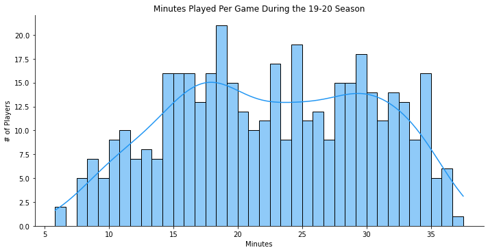

```python
sns.displot(data["MP"],
            bins=38,
            aspect=2,
            kde=True,
            color='#2196f3')

plt.title(f'Minutes Played Per Game During the 19-20 Season')
plt.xlabel('Minutes')
plt.ylabel('# of Players')
plt.show()
```

A player plays a certain amount of minutes per game depending on how valuable they are to the team, as we can see, some play few minutes, while others play around 75% of the game. The distribution for minutes played is somewhat similar to a bimodal distribution, showing that one curve relates to bench players, while the other is related to players who start.

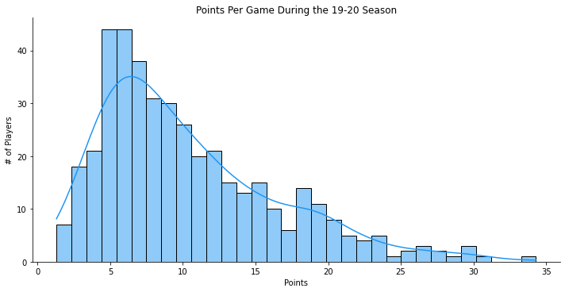

```python
sns.displot(data["PTS"],
            bins=32,
            aspect=2,
            kde=True,
            color='#2196f3')

plt.title(f'Points Per Game During the 19-20 Season')
plt.xlabel('Points')
plt.ylabel('# of Players')
plt.show()
```

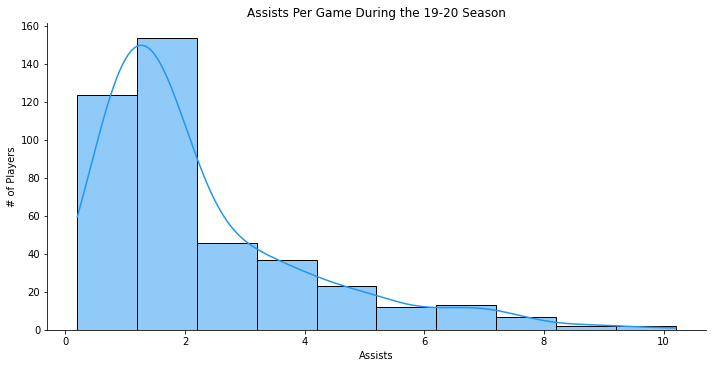

```python
sns.displot(data["AST"],
            bins=10,
            aspect=2,
            kde=True,
            color='#2196f3')

plt.title(f'Assists Per Game During the 19-20 Season')
plt.xlabel('Assists')
plt.ylabel('# of Players')
plt.show()
```

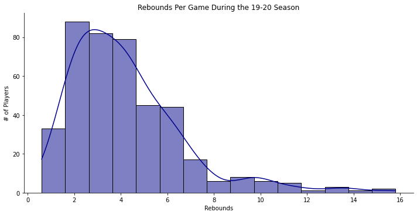

```python
sns.displot(data["TRB"],
            bins=15,
            aspect=2,
            kde=True,
            color='darkblue')

plt.title(f'Rebounds Per Game During the 19-20 Season')
plt.xlabel('Rebounds')
plt.ylabel('# of Players')
plt.show()
```

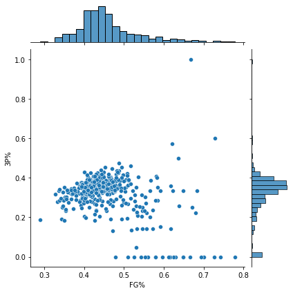

```python
sns.jointplot(data=data, x="FG%", y="3P%")
```

Field goal percentage and 3 point percentage should be somewhat correlated, as 3 pointers count as field goals. However, we do not see a clear correlation between the two variables. Some players are better shooting from long distance, some better from shorter distances, and some are just as good in both areas.

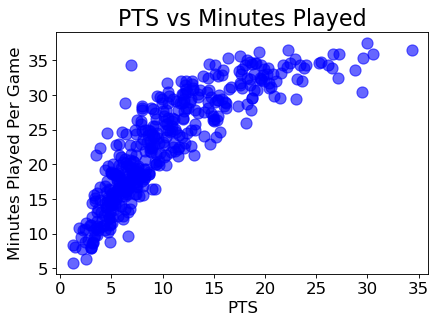

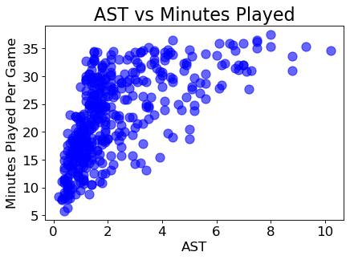

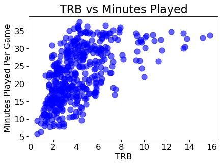

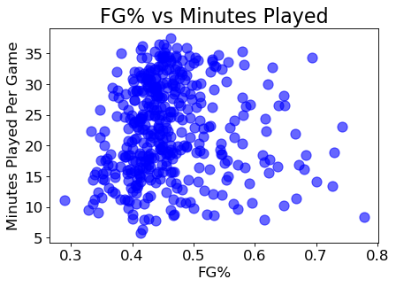

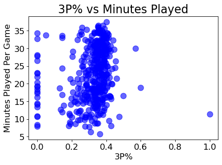

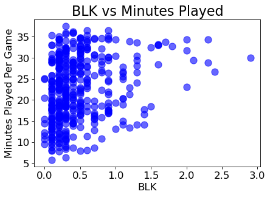

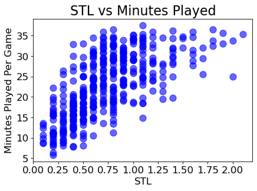

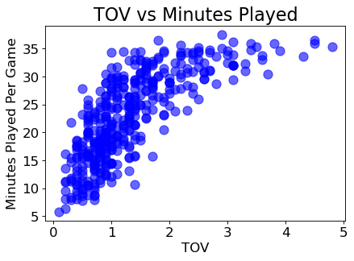

```python
statistics = ["PTS", "AST", "TRB", "FG%", "3P%", "BLK", "STL", "TOV"]

# For each statistic, make a plot of it versus minutes played for every player
for stat in statistics:
    plt.figure(dpi=80)
    plt.scatter(x=data[stat], y=data.MP, c='blue', alpha=0.6, s=100)
    plt.title(f"{stat} vs Minutes Played", fontsize=20)
    plt.xlabel(stat, fontsize=15)
    plt.xticks(fontsize=15)
    plt.yticks(fontsize=15)
    plt.ylabel('Minutes Played Per Game', fontsize=15)
    plt.show()
```

It appears that points, assists, and rebounds all have direct correlations with minutes played, which makes sense, because the better you play, the more stats you have, and so you get more playing time. Interestingly enough, both 3-point percentage and field goal percentage do not have a strong correlation with minutes played per game. And while steals appears to have a correlation with minutes, blocks doesn't appear to have a correlation either. This is possibly because most players who get blocks are among the tallest on the team, while steals are gathered by everyone. Another interesting chart is the relationship between minutes played and turnovers, where the two are positively correlated. Obviously, turnovers are bad, but this relationship may be because they handle the ball more, and so there are more chances to lose the ball.

Why might field goal percentage not have a strong correlation with minutes played? This may be have something to do with certain players' playstyles, such as taking longer range shots, or not being a good shooter but a great passer or rebounder.

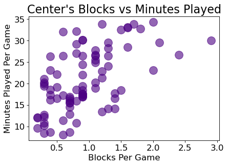

```python
center_data = data[data.Pos == "C"]
plt.figure(dpi=80)
plt.scatter(x=center_data.BLK, y=center_data.MP, c='indigo', alpha=0.6, s=200)
plt.title("Center's Blocks vs Minutes Played", fontsize=20)
plt.xlabel('Blocks Per Game', fontsize=15)
plt.xticks(fontsize=15)
plt.yticks(fontsize=15)
plt.ylabel('Minutes Played Per Game', fontsize=15)
plt.show()
```

Here we can see a much better correlation between blocks and minutes played for centers.

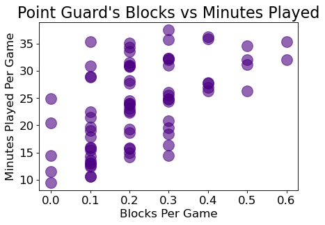

```python
pg_data = data[data.Pos == "PG" ]
plt.figure(dpi=80)
plt.scatter(x=pg_data.BLK, y=pg_data.MP, c='indigo', alpha=0.6, s=200)
plt.title("Point Guard's Blocks vs Minutes Played", fontsize=20)
plt.xlabel('Blocks Per Game', fontsize=15)
plt.xticks(fontsize=15)
plt.yticks(fontsize=15)
plt.ylabel('Minutes Played Per Game', fontsize=15)
plt.show()
```

Conversely, a point guard's blocks are not as correlated with its minutes played. What about 3 point percentage?

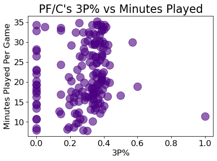

```python
pf_center_data = data[(data.Pos == "PF") | (data.Pos == "C")]
plt.figure(dpi=80)
plt.scatter(x=pf_center_data["3P%"], y=pf_center_data.MP, c='indigo', alpha=0.6, s=200)
plt.title("PF/C's 3P% vs Minutes Played", fontsize=20)
plt.xlabel('3P%', fontsize=15)
plt.xticks(fontsize=15)
plt.yticks(fontsize=15)
plt.ylabel('Minutes Played Per Game', fontsize=15)
plt.show()
```

Power forward's and center's 3 point percentage has a very little correlation with their minutes played.

# Predicting Minutes Played

Now we will try to predict the number of minutes per game a player should average throughout an NBA season depending on the statistics they garner. Due to the many variables (points, assists, rebounds, etc.) that we will be considering, a linear regression model is the best choice.

We will train 80% of NBA player data, and will keep the remaining 20% of the data for testing out-of-sample data. In addition, we will be creating two predictive models, one for guards, and the other for bigger players, due to their major difference in playstyle.

# Predicting a Guard's Minutes Played

Because guards do not gather many rebounds or blocks, they will be excluded from the regression model, as it could cause overfitting of stats.

```python
guard_data = data[(data.Pos == "PG") | (data.Pos == "SG")]

target = guard_data["MP"]
features = guard_data[["PTS", "AST", "FG%", "3P%", "STL"]]

x_train, x_test, y_train, y_test = train_test_split(features, target, test_size=0.2, random_state=10)
# % of training set
train_pct = 100*len(x_train)/len(features)
print(f'Training data is {train_pct:.3}% of the total data.')

# % of test data set
test_pct = 100*x_test.shape[0]/features.shape[0]
print(f'Test data makes up the remaining {test_pct:0.3}%.')
```

```
Training data is 79.9% of the total data.
Test data makes up the remaining 20.1%.
```

## Simple Linear Regression

```python
guard_data_reg = LinearRegression()
guard_data_reg.fit(x_train, y_train)
rsquared = guard_data_reg.score(x_train, y_train)
print(f'Training data r-squared: {rsquared:.2}')
```

```
Training data r-squared: 0.86
```

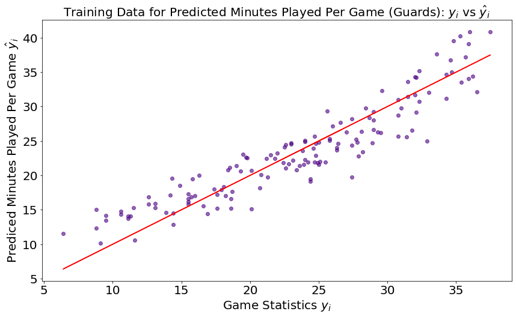

```python
# Calculate the residuals of the regression model
predicted_vals = guard_data_reg.predict(x_train)
residuals = (y_train - predicted_vals)

plt.figure(figsize=(14, 8))
plt.scatter(x=y_train, y=predicted_vals, c='indigo', alpha=0.6)
plt.plot(y_train, y_train, color='red')
plt.title(f'Training Data for Predicted Minutes Played Per Game (Guards): $y _i$ vs $\hat y_i$', fontsize=20)
plt.xlabel('Game Statistics $y _i$', fontsize=20)
plt.xticks(fontsize=20)
plt.yticks(fontsize=20)
plt.ylabel('Prediced Minutes Played Per Game $\hat y _i$', fontsize=20)
plt.show()
```

### Evaluating the Coefficients

```python
reg_coef = pd.DataFrame(data=guard_data_reg.coef_, index=x_train.columns, columns=['Coefficient'])
reg_coef
```

|  | Coefficient |
| --- | --- |
| PTS | 0.77 |
| AST | 0.10 |
| FG% | -12.97 |
| 3P% | 20.17 |
| STL | 6.96 |

It appears that steals and 3-point percentage have a massive impact on minutes per game, and that each point scored is more important than each assist in terms of playing time given. Surprisingly, field goal percentage has a negative effect on minutes played, which is counterintuitive, possibly because the best players take more shots (and more important shots at the end of the game), which can alter their field goal percentage.

### Analyzing Estimated Values and Regression Residuals

Our regression's accuracy also depends on the residuals, which is the difference between the model's predictions ( 𝑦̂ 𝑖 ) and the actual values ( 𝑦𝑖 ).

```python
predicted_vals = guard_data_reg.predict(x_train)
residuals = (y_train - predicted_vals)
```

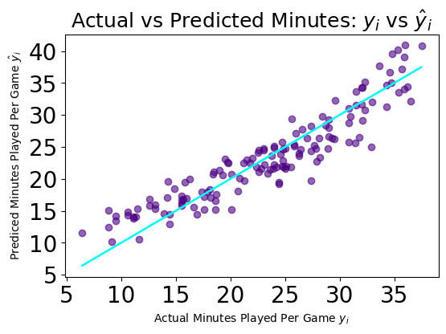

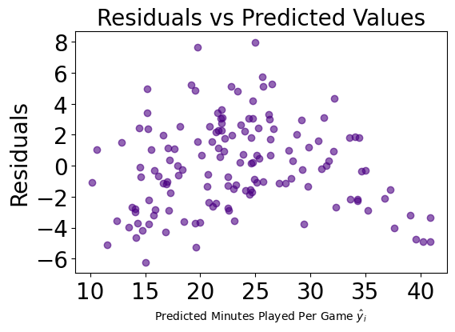

```python
# Regression of Actual vs. Predicted Minutes
plt.figure(dpi=100)
plt.scatter(x=y_train, y=predicted_vals, c='indigo', alpha=0.6)
plt.plot(y_train, y_train, color='cyan')
plt.title(f'Actual vs Predicted Minutes: $y _i$ vs $\hat y_i$', fontsize=18)
plt.xlabel('Actual Minutes Played Per Game $y _i$', fontsize=10)
plt.xticks(fontsize=20)
plt.yticks(fontsize=20)
plt.ylabel('Prediced Minutes Played Per Game $\hat y _i$', fontsize=10)
plt.show()

# Residuals vs Predicted values
plt.figure(dpi=100)
plt.scatter(x=predicted_vals, y=residuals, c='indigo', alpha=0.6)
plt.title('Residuals vs Predicted Values', fontsize=20)
plt.xlabel('Predicted Minutes Played Per Game $\hat y _i$', fontsize=10)
plt.xticks(fontsize=20)
plt.yticks(fontsize=20)
plt.ylabel('Residuals', fontsize=20)
plt.show()
```

For values under 35 minutes per game, the residuals "bounce randomly" around the 0 line, suggesting that the assumption that the relationship is linear is reasonable. Since the residuals form a "horizontal band" around the 0 line, we are able to assume that the variances of the error terms are equal. Values over 40 minutes stand out from the random pattern of the residuals, suggesting that those who play the most minutes per game are outliers, most likely due to their tremendous skill leading to them playing almost the whole game.

## Using the Model to Make a Prediction

```python
x_train = x_train.reset_index()
x_train.head(20)
```

|  | index | PTS | AST | FG% | 3P% | STL |
| --- | --- | --- | --- | --- | --- | --- |
| 0 | 62 | 15.00 | 2.90 | 0.42 | 0.39 | 0.90 |
| 1 | 88 | 5.40 | 1.60 | 0.46 | 0.33 | 0.40 |
| 2 | 417 | 29.60 | 9.30 | 0.44 | 0.36 | 1.10 |
| 3 | 100 | 4.20 | 0.30 | 0.39 | 0.36 | 0.20 |
| 4 | 131 | 4.50 | 1.10 | 0.47 | 0.35 | 0.40 |
| 5 | 60 | 8.10 | 1.40 | 0.40 | 0.33 | 0.90 |
| 6 | 125 | 5.10 | 1.20 | 0.35 | 0.35 | 0.40 |
| 7 | 299 | 9.60 | 5.20 | 0.40 | 0.30 | 1.10 |
| 8 | 54 | 8.90 | 4.00 | 0.44 | 0.34 | 1.10 |
| 9 | 188 | 19.20 | 3.00 | 0.43 | 0.39 | 0.90 |
| 10 | 214 | 25.30 | 10.20 | 0.49 | 0.35 | 1.20 |
| 11 | 137 | 11.20 | 1.70 | 0.42 | 0.39 | 0.50 |
| 12 | 271 | 10.10 | 0.80 | 0.44 | 0.40 | 0.60 |
| 13 | 321 | 3.90 | 1.70 | 0.41 | 0.28 | 1.10 |
| 14 | 257 | 2.40 | 1.30 | 0.47 | 0.35 | 0.30 |
| 15 | 161 | 8.00 | 1.30 | 0.42 | 0.37 | 1.30 |
| 16 | 97 | 9.20 | 1.70 | 0.40 | 0.30 | 0.90 |
| 17 | 354 | 9.90 | 5.40 | 0.43 | 0.32 | 1.20 |
| 18 | 273 | 12.80 | 2.80 | 0.42 | 0.38 | 0.70 |
| 19 | 265 | 6.50 | 5.00 | 0.52 | 0.29 | 0.80 |

```python
x_train[x_train.index == 0]
```

|  | index | PTS | AST | FG% | 3P% | STL |
| --- | --- | --- | --- | --- | --- | --- |
| 0 | 62 | 15.00 | 2.90 | 0.42 | 0.39 | 0.90 |

```python
data[data.index == 62]
```

|  | index | Player | Pos | Age | Tm | G | GS | MP | FG | FGA | ... | FT% | ORB | DRB | TRB | AST | STL | BLK | TOV | PF | PTS |
| --- | --- | --- | --- | --- | --- | --- | --- | --- | --- | --- | --- | --- | --- | --- | --- | --- | --- | --- | --- | --- | --- |
| 62 | 95 | Alec Burks | SG | 28 | TOT | 66 | 19 | 26.60 | 4.90 | 11.60 | ... | 0.89 | 0.70 | 3.50 | 4.30 | 2.90 | 0.90 | 0.30 | 1.40 | 1.90 | 15.00 |

1 rows × 30 columns

```python
features = data[["PTS", "AST", "FG%", "3P%", "STL"]]
average_vals = np.array([15.0, 2.9, .418, .385, 0.9])
stats = pd.DataFrame(data=average_vals.reshape(1, len(features.columns)),
                              columns=features.columns)
stats
```

|  | PTS | AST | FG% | 3P% | STL |
| --- | --- | --- | --- | --- | --- |
| 0 | 15.00 | 2.90 | 0.42 | 0.39 | 0.90 |

```python
estimate = guard_data_reg.predict(stats)[0]
print(f'The regression predicts {estimate:.3} minutes per game for Alex Burks, who played 26.6 minutes per game.')
```

```
The regression predicts 27.7 minutes per game for Alex Burks, who played 26.6 minutes per game.
```

That was pretty accurate. Let's try a player like Matisse Thybulle, who isn't a great offensive player but excels on the defensive end.

Matisse Thybulle: 4.7 PTS, 1.2 AST, 42.3 FG%, 35.7 3P%, 1.4 STL

```python
features = data[["PTS", "AST", "FG%", "3P%", "STL"]]
average_vals = np.array([4.7, 1.2, .423, .357, 1.4])
stats = pd.DataFrame(data=average_vals.reshape(1, len(features.columns)),
                              columns=features.columns)
stats
```

|  | PTS | AST | FG% | 3P% | STL |
| --- | --- | --- | --- | --- | --- |
| 0 | 4.70 | 1.20 | 0.42 | 0.36 | 1.40 |

```python
estimate = guard_data_reg.predict(stats)[0]
print(f'The regression predicts {estimate:.3} minutes per game for Matisse Thybulle, who played 19.8 minutes per game.')
```

```
The regression predicts 22.5 minutes per game for Matisse Thybulle, who played 19.8 minutes per game.
```

Now let's try a star player like Damian Lillard, who put up an unreal statline during this season.

Damian Lillard: 30.0 PTS, 8.0 AST, 46.3 FG%, 40.1 3P%, 1.1 STL

```python
# Starting Point: Average Values in the Dataset
features = data[["PTS", "AST", "FG%", "3P%", "STL"]]
average_vals = np.array([30, 8, .463, .401, 1.1])
stats = pd.DataFrame(data=average_vals.reshape(1, len(features.columns)),
                              columns=features.columns)
stats
```

|  | PTS | AST | FG% | 3P% | STL |
| --- | --- | --- | --- | --- | --- |
| 0 | 30.00 | 8.00 | 0.46 | 0.40 | 1.10 |

```python
estimate = guard_data_reg.predict(stats)[0]
print(f'The regression predicts {estimate:.3} minutes per game for Damian Lillard, who played 37.5 minutes per game.')
```

```
The regression predicts 40.9 minutes per game for Damian Lillard, who played 37.5 minutes per game.
```

Accuracy will be defined as 1 - error. We will calculate error for each guard, add them up, then divide by the total to get the average error.

#### Accuracy = 1 - (MP_A - MP_E)/(MP_E)

```python
MP_A = 0
MP_E = 0
accuracy = 0
count = 0
for i, r in guard_data.iterrows():
    MP_E += guard_data_reg.predict([[r["PTS"], r["AST"], r["FG%"], r["3P%"], r["STL"]]])[0]
    MP_A += r["MP"]
    accuracy += 1 - abs(MP_A - MP_E)/(MP_E)
    count += 1

total_accuracy = accuracy/count
print(f"The guard regression's accuracy was {total_accuracy:.4}")
```

```
The guard regression's accuracy was 0.9919
```

# Predicting a Forward/Center's Minutes Played

Because centers do not shoot many 3-pointers or gather many assists, they will be excluded from the regression model in order to prevent overfitting.

```python
big_players_data = data[(data.Pos == "SF") | (data.Pos == "PF") | (data.Pos == "C")]

target = big_players_data["MP"]
features = big_players_data[["PTS", "FG%", "TRB", "BLK", "STL"]]

x_train, x_test, y_train, y_test = train_test_split(features, target, test_size=0.2, random_state=10)
# % of training set
train_pct = 100*len(x_train)/len(features)
print(f'Training data is {train_pct:.3}% of the total data.')

# % of test data set
test_pct = 100*x_test.shape[0]/features.shape[0]
print(f'Test data makes up the remaining {test_pct:0.3}%.')
```

```
Training data is 79.9% of the total data.
Test data makes up the remaining 20.1%.
```

## Simple Linear Regression

```python
big_players_reg = LinearRegression()
big_players_reg.fit(x_train, y_train)
rsquared = big_players_reg.score(x_train, y_train)
print(f'Training data r-squared: {rsquared:.2}')
```

```
Training data r-squared: 0.82
```

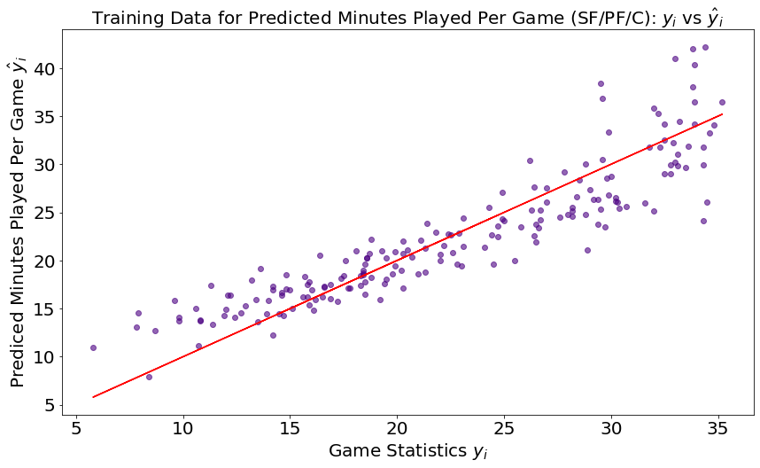

```python
# Calculate the residuals of the regression model
predicted_vals = big_players_reg.predict(x_train)
residuals = (y_train - predicted_vals)

plt.figure(figsize=(14, 8))
plt.scatter(x=y_train, y=predicted_vals, c='indigo', alpha=0.6)
plt.plot(y_train, y_train, color='red')
plt.title(f'Training Data for Predicted Minutes Played Per Game (SF/PF/C): $y _i$ vs $\hat y_i$', fontsize=20)
plt.xlabel('Game Statistics $y _i$', fontsize=20)
plt.xticks(fontsize=20)
plt.yticks(fontsize=20)
plt.ylabel('Prediced Minutes Played Per Game $\hat y _i$', fontsize=20)
plt.show()
```

### Evaluating the Coefficients

```python
reg_coef = pd.DataFrame(data=big_players_reg.coef_, index=x_train.columns, columns=['Coefficient'])
reg_coef
```

|  | Coefficient |
| --- | --- |
| PTS | 0.82 |
| FG% | -11.51 |
| TRB | 0.62 |
| BLK | -0.21 |
| STL | 5.44 |

It appears that steals again have a massive impact on minutes per game, and that each point scored is more important than each rebound in terms of playing time given. The regression model says that blocks are negatively correlated to minutes played, possibly due to the inclusion of small forwards and power forwards with centers.

### Analyzing Estimated Values and Regression Residuals

Our regression's accuracy also depends on the residuals, which is the difference between the model's predictions ( 𝑦̂ 𝑖 ) and the actual values ( 𝑦𝑖 ).

```python
predicted_vals = big_players_reg.predict(x_train)
residuals = (y_train - predicted_vals)
```

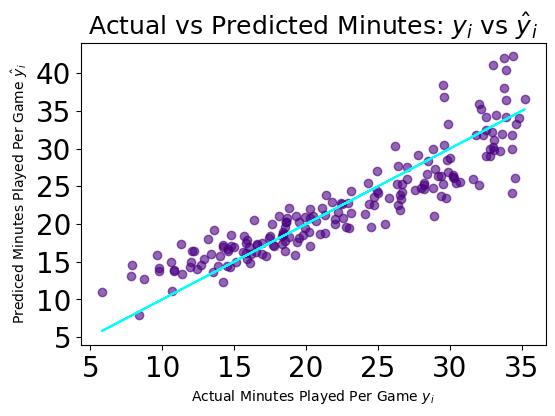

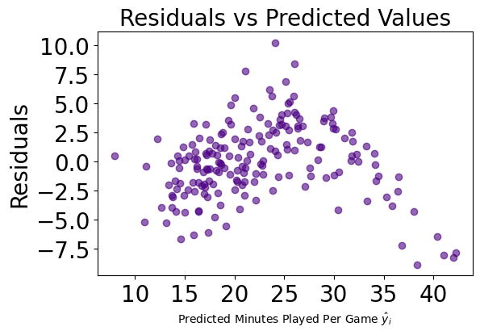

```python
# Regression of Actual vs. Predicted Minutes
plt.figure(dpi=100)
plt.scatter(x=y_train, y=predicted_vals, c='indigo', alpha=0.6)
plt.plot(y_train, y_train, color='cyan')
plt.title(f'Actual vs Predicted Minutes: $y _i$ vs $\hat y_i$', fontsize=18)
plt.xlabel('Actual Minutes Played Per Game $y _i$', fontsize=10)
plt.xticks(fontsize=20)
plt.yticks(fontsize=20)
plt.ylabel('Prediced Minutes Played Per Game $\hat y _i$', fontsize=10)
plt.show()

# Residuals vs Predicted values
plt.figure(dpi=100)
plt.scatter(x=predicted_vals, y=residuals, c='indigo', alpha=0.6)
plt.title('Residuals vs Predicted Values', fontsize=20)
plt.xlabel('Predicted Minutes Played Per Game $\hat y _i$', fontsize=10)
plt.xticks(fontsize=20)
plt.yticks(fontsize=20)
plt.ylabel('Residuals', fontsize=20)
plt.show()
```

## Using the Model to Make a Prediction

Entering players' stats, we will be able to see how accurate the model is at predicting minutes played per game. Let's start out with an average forward, such as Bobby Portis.

Bobby Portis: 10.1 PTS, 45% FG, 5.1 TRB, 0.3 BLK, 0.5 STL

```python
features = data[["PTS", "FG%", "TRB", "BLK", "STL"]]
average_vals = np.array([10.1, .45, 5.1, 0.3, 0.5])
stats = pd.DataFrame(data=average_vals.reshape(1, len(features.columns)),
                              columns=features.columns)
stats
```

|  | PTS | FG% | TRB | BLK | STL |
| --- | --- | --- | --- | --- | --- |
| 0 | 10.10 | 0.45 | 5.10 | 0.30 | 0.50 |

```python
estimate = big_players_reg.predict(stats)[0]
print(f'The regression predicts {estimate:.3} minutes per game for Bobby Portis, who played 21.1 minutes per game.')
```

```
The regression predicts 22.1 minutes per game for Bobby Portis, who played 21.1 minutes per game.
```

Let's try a defensive star like Rudy Gobert.

Rudy Gobert: 15.1 PTS, 69.3% FG, 10.1 TRB, 2.0 BLK, 0.8 STL

```python
features = data[["PTS", "FG%", "TRB", "BLK", "STL"]]
average_vals = np.array([15.1, .693, 10.1, 2.0, 0.8])
stats = pd.DataFrame(data=average_vals.reshape(1, len(features.columns)),
                              columns=features.columns)
stats
```

|  | PTS | FG% | TRB | BLK | STL |
| --- | --- | --- | --- | --- | --- |
| 0 | 15.10 | 0.69 | 10.10 | 2.00 | 0.80 |

```python
estimate = big_players_reg.predict(stats)[0]
print(f'The regression predicts {estimate:.3} minutes per game for Rudy Gobert, who played 34.3 minutes per game.')
```

```
The regression predicts 27.8 minutes per game for Rudy Gobert, who played 34.3 minutes per game.
```

That was less accurate than usual. This is likely because Gobert doesn't take too many shots, so he doesn't score many points, and so this harms him with respect to the regression model. Let's try a below-average player like Marvin Williams.

Marvin Williams: 5.9 PTS, 44.6% FG, 3.2 TRB, 0.5 BLK, 0.6 STL

```python
features = data[["PTS", "FG%", "TRB", "BLK", "STL"]]
average_vals = np.array([5.9, .446, 3.2, 0.5, 0.6])
stats = pd.DataFrame(data=average_vals.reshape(1, len(features.columns)),
                              columns=features.columns)
stats
```

|  | PTS | FG% | TRB | BLK | STL |
| --- | --- | --- | --- | --- | --- |
| 0 | 5.90 | 0.45 | 3.20 | 0.50 | 0.60 |

```python
estimate = big_players_reg.predict(stats)[0]
print(f'The regression predicts {estimate:.3} minutes per game for Marvin Williams, who played 19.5 minutes per game.')
```

```
The regression predicts 18.1 minutes per game for Marvin Williams, who played 19.5 minutes per game.
```

In order to calculate the accuracy, we use the same formula as before.

#### Accuracy = 1 - (MP_A - MP_E)/(MP_E)

```python
MP_A = 0
MP_E = 0
accuracy = 0
count = 0
for i, r in big_players_data.iterrows():
    MP_E += big_players_reg.predict([[r["PTS"], r["FG%"], r["TRB"], r["BLK"], r["STL"]]])[0]
    MP_A += r["MP"]

    accuracy += 1 - abs(MP_A - MP_E)/(MP_E)
    count += 1

total_accuracy = accuracy/count
print(f"The SF/PF/C regression's accuracy was {total_accuracy:.4}")
```

```
The SF/PF/C regression's accuracy was 0.9875
```

We can see that the per-game statistics of a SF/PF/C can predict their minutes played at a high accuracy.

# Conclusion

There definitely could've been more statistics entered, such as turnovers, free throw percentage, and fouls, which are all other ways to measure a player's performance. Also, there could have been a regression model built for each position, but for simplicity I narrowed it down to guards and forwards/centers. This would increase accuracy even more because typically shooting guards are better at shooting, while point guards are better at gathering assists. Also, centers get more blocks, and small forwards are all-around players, and different variables would be used for each position. In addition, I could have changed all the statistics so that each data point is divided by minutes played, so you can see who is the most efficient in statistics gathered per minute, which may help determine the minutes a player should get when a player is getting significantly less or more minutes than they should. One can also use datasets with more advanced data for better modeling.

These models can definitely be used by an NBA basketball coach in order to determine if a player is playing enough or getting too much playing time, as the regression model would tell them how many minutes played the typical player with those stats would have. It can also help them determine whether a player on another team is undervalued compared to their playing time, which may influence their decision to trade for them if the model tells them they should be getting more playing time. Conversely, if a player is getting too many minutes, a coach may want to trade them away. NBA statistics are overall consistent, so one could use this for the current season as well.

Something to consider is, do the minutes affect the statistics more than the statistics affect the minutes played? A player who doesn't play enough may not have enough chances to prove themselves to play more minutes. There also could be other good players in the same position on the same team, meaning less minutes for that player.